# 10 — Scaling

Buying the search · SOC4180 Robot and AI

Hong Jeong

## The number we have been avoiding

Three weeks of training runs, and every one ended the same way: *not enough steps*.

- Week 8: 30k steps. Learned not to fall.
- Week 9: 40k steps. Left one local optimum for a worse one.

A tuned locomotion run in the literature uses **150 million** steps.

We have been running **0.03%** of a real experiment and drawing conclusions from it. Today we find out what that costs and how it is bought.

## The arithmetic of a run

A training run is $N$ environment steps. With $n$ environments each stepping at $r$ steps per second, and a learner that needs $\ell$ seconds per update of $B$ steps:

$$T_{\text{wall}} \;=\; \frac{N}{n\,r} \;+\; \frac{N}{B}\,\ell
\qquad\text{(collect)} \qquad\;\; \text{(learn)}$$

The first term is what parallelism attacks. The second does not shrink with $n$ — it is the serial part, and it caps the speed-up the way Amdahl’s law says: with a fraction $s$ of the time spent learning, no number of environments beats $1/s$.

Two things follow, and today measures both:

- $n$ only helps if the $n$ environments **really run at once**
- once collection is cheap, the learner’s $\ell$ is the wall, and that is why the network is small, the batch is large, and everything is compiled

## Where the time goes

Not in the neural network. In the physics.

```
/home/runner/work/soc4180/soc4180/.venv/bin/python3: No module named pip
/home/runner/work/soc4180/soc4180/.venv/bin/python3: No module named pip
soc4180 0.1.0 | playground OK
```

Two habits in that cell, both learned the hard way:

**Upgrade unconditionally.** `try: import X / except ImportError: install X` can never deliver an update — the import succeeds against a stale copy and the install never runs. You then get an `AttributeError` for something that exists perfectly well in the repository.

**Install before importing.** pip rewrites files on disk; it cannot replace a module the interpreter has already loaded.

```
one environment :     3338 control steps/s
                      33,384 physics steps/s (10 per control step)
150M steps at this rate:   12.5 hours (0.5 days)
```

## The obvious idea, and why it fails

Run many environments at once. Stable-Baselines3 offers `DummyVecEnv`:

```
  DummyVecEnv,  1 envs :    3156 steps/s
  DummyVecEnv,  4 envs :    3207 steps/s
  DummyVecEnv, 16 envs :    3141 steps/s
```

Sixteen environments, **the same throughput as one**.

`DummyVecEnv` steps them *in a loop*. It batches the policy’s forward pass, which was never the bottleneck. The physics still runs one environment at a time on one core.

> “Vectorised” does not mean “parallel”.

## Real parallelism, and its ceiling

`SubprocVecEnv` puts each environment in its own process, so the physics really does run at the same time:

```
CPU cores available here: 4

  SubprocVecEnv, 2 envs :    4504 steps/s
  SubprocVecEnv, 4 envs :    4118 steps/s
  SubprocVecEnv, 8 envs :    5014 steps/s
```

## Vectorised against parallel, drawn

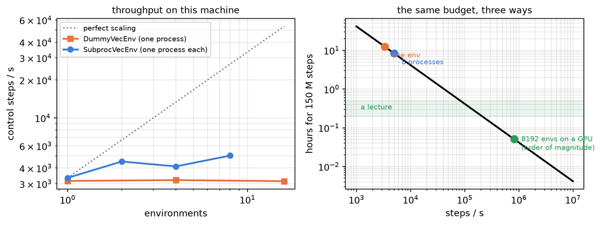

## Physics on the GPU

The way out is not more cores. It is a different kind of processor.

**MJX** is MuJoCo rewritten in JAX. The same model, the same contact solver — but expressed so that XLA can compile it and run **thousands of copies at once** on a GPU.

Two ideas make it work:

- **`jit`** — compile the whole step function once, ahead of time, instead of interpreting Python 500 times a second
- **`vmap`** — take a function written for *one* robot and vectorise it over a batch dimension, so 8192 robots step in one GPU kernel launch

The price is real: everything must be expressible as fixed-shape array operations. **No Python branching, no variable-length loops, no early exit** — which is why an MJX environment reads so differently from the one we wrote.

## `vmap`, drawn

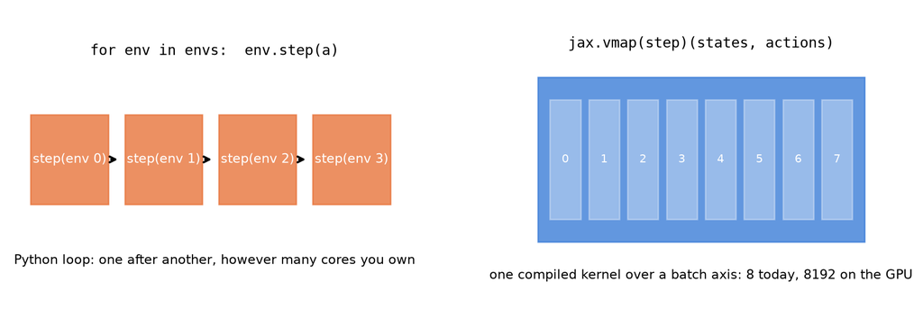

The price, again: every robot must take the same instructions. No `if`, no early exit, no variable-length anything. The batch is one array.

## What the professionals actually run

`mujoco_playground` ships tuned configurations. These are read from the library, not quoted from memory:

```
BerkeleyHumanoidJoystickFlatTerrain
    timesteps    150,000,000
    parallel envs      8,192
    batch size           256
    discounting         0.97
Op3Joystick
    timesteps    100,000,000
    parallel envs      8,192
    batch size           256
    discounting         0.97
```

8192 environments in parallel, 150 million steps. Our entire Week 9 experiment was **0.027%** of one of these.

## A detail worth noticing

```
  policy_hidden_layer_sizes    (512, 256, 128)
  policy_obs_key               state
  value_hidden_layer_sizes     (512, 256, 128)
  value_obs_key                privileged_state
```

Look at the last two lines. The **policy** reads `state`; the **value function** reads `privileged_state`.

That is the asymmetric actor–critic from Week 6, in production. The critic is allowed to see things no real robot can measure — body height, contact forces, terrain — because the critic is thrown away after training. The policy sees only what an IMU and joint encoders provide, so it remains deployable.

**The discipline we imposed in Week 6 is exactly what the state of the art does.**

## Three things that will bite you

Every one of these was hit while preparing this lab, and none is your code being wrong.

**1. `ModuleNotFoundError: mujoco_playground`.** It is not part of `soc4180[rl]`; install `playground` separately.

**2. `AttributeError: type object 'int' has no attribute 'WARP'`.** The env config defaults to `impl="warp"`, the newer MJWarp backend, which needs the separate `mujoco-warp` package. Override to **`impl="jax"`**.

**3. Two removed JAX APIs.** Depending on which library trips first you get

```
AttributeError: jax.core.get_opaque_trace_state was ... removed in JAX v0.11.0
AttributeError: jax.device_put_replicated is deprecated
```

The first is **flax**, the second is **brax**. Both still call APIs that JAX removed in 0.11, and brax requires only `jax>=0.4.6` — no upper bound — so pip installs a broken combination by default. **Colab’s preinstalled JAX is 0.11, so it is broken out of the box.**

## Repairing it in three lines

Two fixes exist. **Pinning `jax==0.9.2`** — the newest release still carrying both functions — works, but on Colab it means a large download *and* a runtime restart on every fresh session, because pip cannot replace a module Python has already imported.

Cheaper: put the two functions back. JAX’s own deprecation messages name their replacements.

```
get_opaque_trace_state: patched from jax.extend.core
device_put_replicated : patched
jax 0.11.1 | devices: [CpuDevice(id=0)]
```

`get_opaque_trace_state` simply moved to `jax.extend.core`. `device_put_replicated` stacked an array once per device, which is a few lines of `jnp.stack`. Neither is deep magic, and this is the kind of patch you will write repeatedly in this field.

Note it is written out here rather than imported from `soc4180`. A cell whose job is repairing a broken environment should not depend on a package install having succeeded — that just adds a second thing that can fail.

**Pin versions in a course repo and bump them once a semester.** Half of these failures are simply the calendar moving.

## Running it

This needs a **GPU runtime**, and it will not run on a Windows machine at all — JAX publishes CUDA wheels for Linux only.

`registry.load` clones its **own** copy of Menagerie on first call — about 40 seconds, separate from the copy `soc4180` uses.

**The first line takes the longest.** Brax compiles the entire training loop through XLA before a single step runs, so expect a minute or two of silence before the first progress line — then the rest come quickly. That gap is compilation, not a hang.

**Calibrate the budget yourself.** 5M steps is a starting point. Read the seconds-per-step from the progress output and scale `num_timesteps` so the run lands where you want it; an A100 is substantially faster than the T4 this figure was chosen for.

## Track A and Track B

**Track A — required, ≤15 minutes.** Run the truncated configuration above. Success is **not** a walking robot. Success is:

> episode reward and episode length both trending upward, and a rollout that shows a recognisable attempt at a gait.

**Track B — optional.** The full 150M-step budget, launched at the start of the lab and collected at the end, or run overnight with checkpoints saved to Drive.

Colab disconnects. **Checkpoint every evaluation**, or a run that dies at minute 80 of 90 leaves you with nothing.

## Reading a learning curve

You will be judged on the diagnosis, not the policy. Four shapes to recognise:

| Curve | Likely cause |
| --- | --- |
| Flat from the start | broken observation, wrong action scale, or no gradient reaching the policy |
| Rises then collapses | learning rate too high, or the exploration bug from Week 8 |
| Rises then plateaus below target | local optimum — Week 9’s standing robot |
| Rises smoothly, slowly | it is working; you need more steps |

Always plot **episode length** alongside reward. A rising reward with flat episode length usually means the policy found a way to score without surviving — and that is a reward bug, not a training one.

## The four shapes, sketched

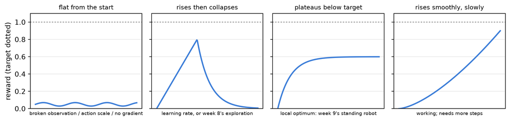

Sketches, not data: the point is the *shape*. Plot episode length underneath each, always.

## What the budget actually buys

[output not shown]

Three orders of magnitude separate the top row from the bottom, and nothing else about the algorithm changes. **PPO was never the limitation.**

Our conclusions from Weeks 8 and 9 were not wrong — but they were conclusions about *underfunded* runs, and it is worth being honest about which findings survive a real budget.

## Lab class: on your laptop

```bash
uv run weeks/10-scaling/lab_many.py
```

`N_ROBOTS` copies of the G1 in **one** scene — one model, one `mj_step`, one controller driving all of them. `+`/`-` add and remove robots, `F` randomises friction and mass, `P` benchmarks processes, `ENTER` prints robot-steps/s against `predict_rate` (complete; `COST_EXPONENT` is what you correct).

| Step | Do | Right looks like |
| --- | --- | --- |
| 1 | `ENTER`, `+` `+` `+`, correct `COST_EXPONENT` | physics-only throughput nearly flat (p ≈ 1.09); walking climbs because one IK call is shared |
| 2 | `P` | 16,822 / 33,382 / 62,410 / 130,429 robot-steps/s for 1/2/4/8 processes here |
| 3 | hours for 150 M | 2.5 h in one process, 0.2 h at 16 processes, on 36 cores |
| 4 | `F` | robots that diverge; what a policy trained on all of them would have to learn |
| 5 | `+` until 0.25× real time | ~62 µs of physics per robot-step; 0.5 ms for the controller |

## Lab class: `many.py`, two ways to more robot-steps

```bash
uv run weeks/10-scaling/many.py --robots 1 2 4 8 16 --procs 1 2 4 8 16
```

Per scene size, two rates — held (physics only) and walking (one shared controller call per step) — then processes with one robot each, the 150 M budget, and the largest scene walking.

| n robots | nbody | physics only, robot-steps/s | walking, robot-steps/s |
| --- | --- | --- | --- |
| 1 | 31 | 16,164 | 1,544 |
| 4 | 121 | 14,686 | 4,448 |
| 16 | 481 | 13,064 | 8,656 |

Processes: 16,822 → 33,382 → 62,410 → 130,429 → 199,062 for 1, 2, 4, 8, 16. One process gets no more physics out of more robots; processes scale until the cores run out; a GPU is the same idea with thousands of lanes. Calls: `MjSpec.from_file`, `add_frame`, `attach_body`, `compile`, `np.tile(ctrl, n)`; `multiprocessing.get_context("spawn").Pool`; `launch_viewer(passive=True)`.

## Exercises

1. **Measure your own ceiling.** Run the `SubprocVecEnv` sweep on Colab. How many cores do you get, and where does throughput stop improving?
2. **Do the arithmetic.** At your measured CPU rate, how long is 150M steps? How many GPU-equivalents of CPU would you need?
3. **Track A.** Run the truncated MJX configuration. Plot reward *and* episode length. Classify the curve using the table above.
4. **Halve the environments.** Set `num_envs` to 1024 and then 4096 at a fixed step budget. Does wall-clock scale as you expect? What does that say about where the GPU time goes?
5. **Break it deliberately.** Set the learning rate to 3e-2 and describe the curve’s shape before looking.
6. **Checkpoint discipline.** Write a callback that saves to Drive every evaluation and reloads on restart. Test it by interrupting the run.

## Next week

**Week 11 — domain randomization.** With a real budget available, the question changes from *can it learn* to *will it survive anything other than the exact simulator it learned in*.

We randomise mass, friction, and actuation during training, and measure what robustness costs.